# CS02 - Predicting Annual Air Pollution

Jiayi Xue, Nick Liu, Roxana Chen, Sehee Kim, Jorge Ramos

## Background

With health impacts such as asthma, lung function, low birthweight, and viral infection being globally widespread, air pollution is at fifth place for global risk factors by total number of deaths from all causes in 2017 [^1]. With particles as small as 0.43 micrometers reaching into the human respiratory system, it is extremely difficult to catch visible effects until it is too late. This awareness has been inconsistent throughout the world, with some countries exceeding the World Health Organization (WHO) guideline for healthy air while other countries such as Africa and Asia displaying extremely poor air quality [^2]. Despite the fact that air quality has improved throughout time in the United States, it is still a major health risk. With air pollution monitors being sparsely spread throughout the contiguous United States, this may lead to inaccurate readings in significant regions often minimizing our knowledge on the relationship between air pollution and its health impacts. To reduce this gap, data from these monitors along with multiple external factors that manipulate air pollution concentration (urbanization, population density, road length, emissions, etc.,) is taken into account to make further analysis. Taking all these factors into consideration, **with what accuracy can we predict US annual average air pollution concentration?** Depending on this accuracy, we can take efficient and practical measures to avoid prominent health issues while raising awareness.

Extending, **can we find a more parsimonious model that we can utilize for various situations such as not having all the variables?** Occam’s Razor states that with a model of multiple predictors, it is best to minimize the amount of predictors in order to improve efficiency while maintaining accuracy: a parsimonious model. With this principle and using feature selection, our team found another model that was more practical and efficient to use when predicting air pollution concentration. Specifically, we can still find the concentration for different areas even when we do not and cannot measure all the predictors.

**This is our data variables and their description**

| Variable | Description |
| --- | --- |
| id | monitor number (country number before the decimal, monitor number after the decimal) |
| fips | federal information processing standard number for the country where the monitor is located |
| lat | latitude of the monitor in degrees |
| lon | longitude of the monitor in degrees |
| state | state where the monitor is located |
| county | county where the monitor is located |
| city | city where the monitor is located |
| CMAQ | estimated values of air pollution from Community Multiscale Air Quality, a monitoring system that uses chemistry and weather data to predict the air pollution |
| zcta | Zip Code Tabulation Area where the monitor is located (2010) |
| zcta_area | land area of the zip code area in meters squared (2010) |
| zcta_pop | population in the zip code area (2010) |
| country_area | land area of the county of the monitor in meters squared |
| country_pop | population of the county of the monitor |
| imp_a(radius around the monitor) | impervious surface measure such as roads, concrete, parking lots, and buildings as a measure of development |
| Log_dist_to_prisec | log (natural log) distance to a primary or secondary road from the monitor |
| log_pri_length_(radius around the monitor | count of primary road length in meters in a circle in various radius |
| log_prisec_length_(radius around the monitor) | count of primary and secondary road length in meters in a circle in various radius |
| log_nei_2008_pm25_sum_(radius of distance around the monitor) | tons of emissions from major sources database (annual data) sum of all sources within a circle in various radius meters of distance around the monitor |
| popdens_zcta | population density (number of people per kilometer squared area of zcta) |
| nohs | percentage of people in zcta area where the monitor is that do not have a high school degree |
| somehs | percentage of people in zcta area where the monitor whose highest formal educational attainment was some high school education |
| hs | percentage of people in zcta area where the monitor whose highest formal educational attainment was completing a high school degree |
| somecollege | percentage of people in zcta area where the monitor whose highest formal educational attainment was completing some college education |
| associate | percentage of people in zcta area where the monitor whose highest formal educational attainment was completing an associate degree |
| bachelor | percentage of people in zcta area where the monitor whose highest formal educational attainment was a bachelor’s degree |
| grad | percentage of people in zcta area where the monitor whose highest formal educational attainment was a graduate degree |
| pov | percentage of people in zcta area where the monitor is that lived in poverty in 2008 |
| hs_orless | percentage of people in zcta area where the monitor whose highest formal educational attainment was a high school degree or less (sum of nohs, somehs, and hs) |
| urc2006 & urc2013 | urban-rural classification of the county where the monitor is located (1 - totally urban and 6 - completely rural) |
| aod | Aerosol Optical Depth measurement from NASA satellite used as a proxy of particulate pollution |

### Load packages

```r
library(tidyverse)
library(tidymodels)
library(sf)
library(maps)
library(rnaturalearth)
library(patchwork)
```

## The Data

### Data Import

```r
pm <- read_csv("pm25_data.csv")
```

### Data Wrangling

In our data wrangling, we performed factoring, data splitting, and cross validation. We factored `id`, `fips`, `zcta` to ensure they are treated as categorical values in the model. We also simplified the city feature to be binary, distinguishing monitors in cities and out of cities.

```r
# Converting to factors
pm <- pm |>
  mutate(across(c(id, fips, zcta), as.factor))

# Making it clear which monitor is in a city or not in a city
pm <- pm |>
  mutate(city = case_when(city == "Not in a city" ~ "Not in a city",
                          city != "Not in a city" ~ "In a city"))
```

Data splitting is critical in model prediction, we split data into training and testing categories. We use the training set to train the model by finding patterns in the data and we use the testing set to evaluate the model performance. The goal of data splitting is to test the model on data it has never seen during training to check for overfitting and assess its performance. We initiate the total dataset (876), split ⅔ of it into the training set (584) and ⅓ of it into the testing set (292). To enhance our model’s generalizability, we implemented 4-fold cross-validation using the vfold_cv function from the rsample package. The 4-fold cross-validation involves partitioning the training data set into 4 equal folds. The model is trained on three folds and validated on the fourth, cycling through all folds as the validation set. This ensures that the model is evaluated on multiple subsets of the training data and provides a more robust and reliable model. Cross-validation also helps mitigate the risk of overfitting and increases its generalizability.

```r
# setting a seed
set.seed(1234)

# Splitting data into train/testing split

pm_split <- rsample::initial_split(data = pm, prop = 2/3)
pm_split
```

```
## <Training/Testing/Total>
## <584/292/876>
```

```r
train_pm <- rsample::training(pm_split)
test_pm <- rsample::testing(pm_split)

# Performing cross validation
vfold_pm <- rsample::vfold_cv(data = train_pm, v = 4)
vfold_pm
```

```
## #  4-fold cross-validation
## # A tibble: 4 × 2
##   splits            id
##   <list>            <chr>
## 1 <split [438/146]> Fold1
## 2 <split [438/146]> Fold2
## 3 <split [438/146]> Fold3
## 4 <split [438/146]> Fold4
```

## Analysis

### Exploratory Data Analysis (EDA)

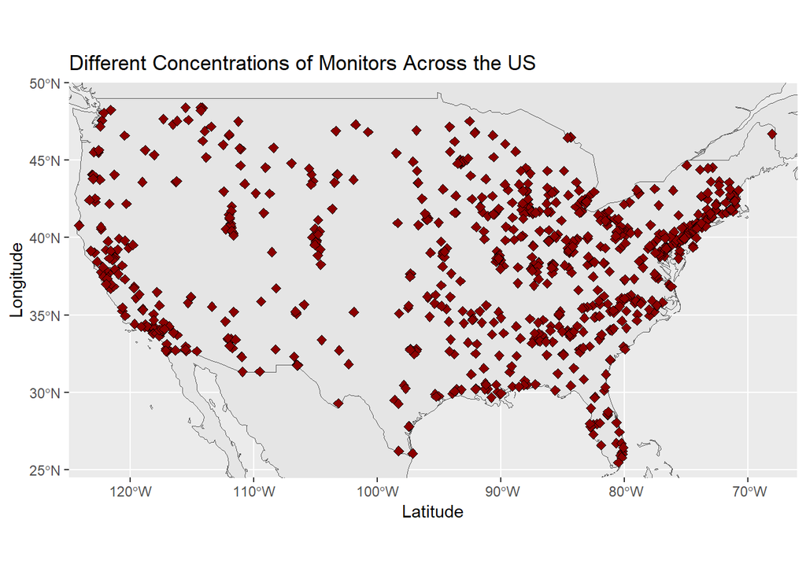

```r
# loading the world map
world <- ne_countries(scale = "medium", returnclass = "sf")

# plotting the monitor locations onto a world map
ggplot(data = world) +
    geom_sf() +
    coord_sf(xlim = c(-125, -66), ylim = c(24.5, 50),
             expand = FALSE)+
    geom_point(data = pm, aes(x = lon, y = lat), size = 2,
               shape = 23, fill = "darkred") +
    labs(title = "Different Concentrations of Monitors Across the US", x = "Latitude", y = "Longitude")
```

Exploring the data, we first mapped out all of the monitors onto a map of the US. From this map visualization, we are able to see how the amount of monitors is not a consistent spread across the US, but rather many monitors tend to be bunched up in specific areas while very sparse in others. Specifically, monitors tend to have large concentrations along the coast, possibly due to having a higher population along coastlines.

```r
# counting the monitors in each state, listed from highest to lowest
count(pm, state) |>
  arrange(desc(n))
```

```
## # A tibble: 49 × 2
##    state              n
##    <chr>          <int>
##  1 California        85
##  2 Ohio              44
##  3 Illinois          38
##  4 Indiana           36
##  5 North Carolina    35
##  6 Pennsylvania      32
##  7 Michigan          30
##  8 Florida           29
##  9 Georgia           28
## 10 Texas             27
## # ℹ 39 more rows
```

Looking further, specifically at the amount of monitors in each state, we can see the concentration of monitors is not only different across the country, but also different across states. For example, California has the highest amount of monitors at 85, which is almost double the amount of monitors than there is for the state with the second highest amount of monitors, being Ohio with 44. With this, we can see the inconsistency across states, and know that the varied spread of monitors across the US as seen in the previous world map plot is not necessarily dictated by state boundaries.

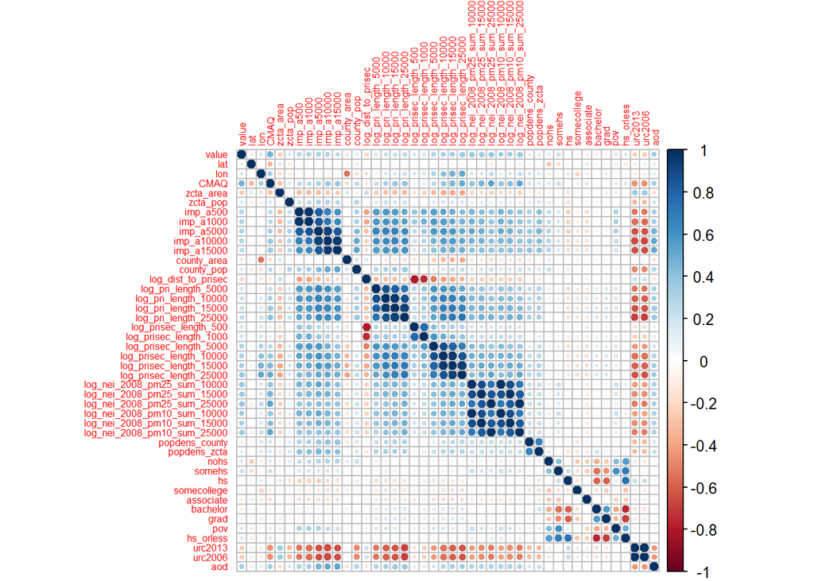

```r
# creating a correlation plot for all the variables
pm_cor <- cor(pm |> dplyr::select_if(is.numeric))
corrplot::corrplot(pm_cor, tl.cex = 0.5)
```

The correlation plot above shows both strength and direction of correlation between all of the variables in the dataset. For example, a deep blue color at the intersection of two variables indicates a strong, positive correlation, while a deep red color at the intersection of two variables shows a strong, negative correlation.

As the plot shows, each group of variables (i.e. log_pri_length_5000, log_pri_length_10000, etc. would be an example of variables in the same group) are highly positively correlated with each other, which is to be expected because the variables are measuring the same parameter, just on different scopes (ex. log_pri_length_5000 and log_pri_length_10000 are both measuring primary road length, but for different radii). A few more notable observations from the plot are that: - CMAQ, a predictive measure of air pollution, is the most highly (and positively) correlated variable with value, the variable which reflects the actual measure of air pollution - CMAQ is more highly correlated with value than aod, another predictive air pollution variable - CMAQ is relatively strongly negatively correlated with urc measurements, which are a classification scale of the urban/rural level of an area.

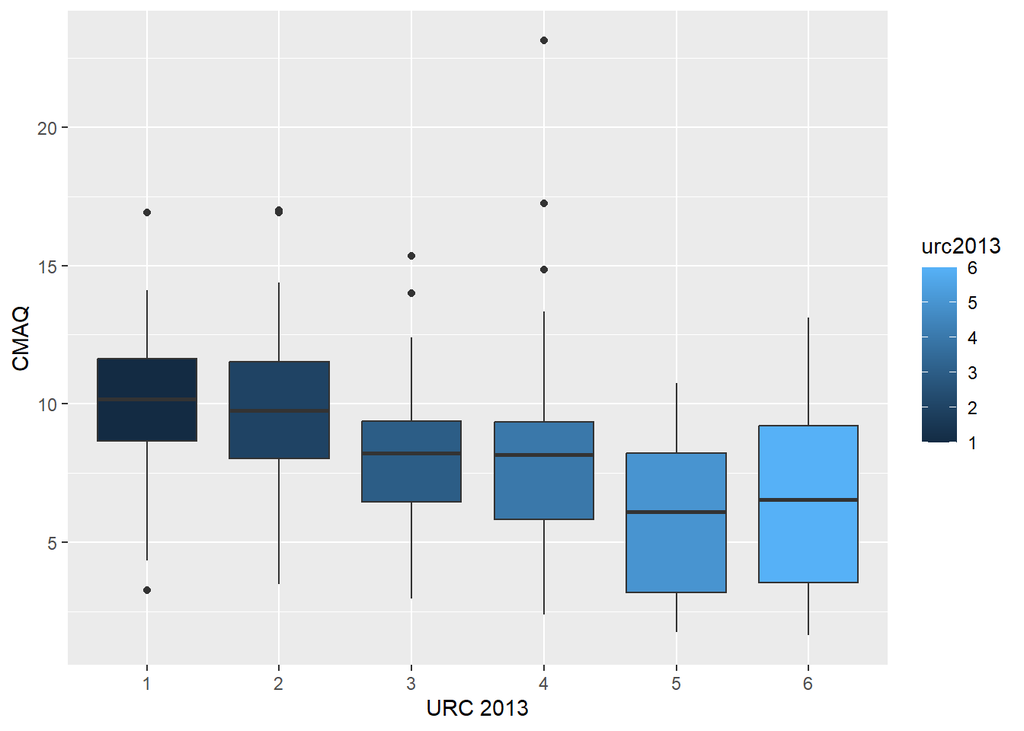

```r
# plotting the relationship between CMAQ & urc_2013
ggplot(pm, aes(x = factor(urc2013), y = CMAQ, fill = urc2013)) +
  geom_boxplot() +
  labs(x = "URC 2013")
```

Based on the previous correlation seen, we looked further into the relationship between CMAQ and the urc_2013 variables and found that the more rural an area is (on the urban-rural classification scale, 1 is more urban and 6 is more rural), the lower the predicted value of air pollution in the area (lower CMAQ value). The opposite is also true, as seen in the graph above; the more urban an area is, the higher the predicted value of air pollution (higer CMAQ value).

### Model

After splitting the data into testing and training sets, we built the model using tidymodels. The steps start with creating “recipe” and assigning variable roles. Then, we specify the model, engine, and mode. Next, we fit workflow and get predictions. Finally, we use the predictions to find performance metrics.

```r
# Recipe with all predictors
RF_rec <- recipe(train_pm) |>
    # assign roles for the columns
    update_role(everything(), new_role = "predictor")|>
    update_role(value, new_role = "outcome")|>
    update_role(id, new_role = "id variable") |>
    update_role("fips", new_role = "county id") |>

    # step_novel assigns a previously unseen factor level to a new value
    step_novel("state") |>

    # converts string to factors
    step_string2factor("state", "county", "city") |>

    # removing redundancy
    step_rm("county") |>
    step_rm("zcta") |>
    # removing highly correlated variables
    step_corr(all_numeric())|>
    # removing near zero variance predictors
    step_nzv(all_numeric())
```

The purpose of recipe() function is to provide a standardized structure to ensure that the data is in the correct format for modeling. The recipe, RF_rec, defines a pre-processing pipeline for the training dataset to prepare for the model. In the recipe, we initially assign all variables in the dataset as predictors. Then, we override the role for the column value as the “outcome”, which is our target predicting variable. `id` is specified as an “id variable,” which means it won’t be used as a predictor or outcome. The “fips” column was assigned the new role of “county id” which is used for grouping but not for predicting.

After creating the recipe(), several step_*() functions are added to define specific pre-processing steps. step_novel() is used for the “state” variable to get all cross-validation folds to work by ensuring that any unseen level in the “state” variables which wasn’t observed during training will be assigned a placeholder value to prevent errors such as overfitting. We then convert the string columns “state”, “county”, and “city” to factors, making them suitable for categorical handling in modeling. Next, we removed columns “county” and “zcta” from the dataset as they are redundant, removed numeric variables that are highly correlated with each other, and removed numeric predictors with near-zero variance whose values barely change across observations, which contribute very little to the model prediction.

```r
# untuned model to find most important parameters
RF_PM_model <- parsnip::rand_forest(mtry = 10, min_n = 3) |>
  set_engine("randomForest") |>
  set_mode("regression")
```

A tuned random forest model was then initialized to improve predictive performance. Two hyperparameters, mtry and min_n, were included for tuning: mtry specifies the number of features randomly selected at each split in a tree, while min_n defines the minimum number of observations required in a node to allow further splitting. Rather than manually testing different values, the tune() function was used to automate the hyperparameter optimization process. The model engine was set to “randomForest,” specifying the algorithm for building the random forest, and set_mode(“regression”) was used to indicate that the target variable is continuous (e.g. air pollution levels).

```r
# untuned workflow
RF_wflow <- workflows::workflow() |>
  workflows::add_recipe(RF_rec) |>
  workflows::add_model(RF_PM_model)

# fit with training set
RF_wflow_fit <- parsnip::fit(RF_wflow, data = train_pm)

# initializing a tuned random forest model
tune_RF_model <- rand_forest(mtry = tune(), min_n = tune()) |>
  set_engine("randomForest") |>
  set_mode("regression")

# create workflow
RF_tune_wflow <- workflows::workflow() |>
  workflows::add_recipe(RF_rec) |>
  workflows::add_model(tune_RF_model)

# find number of cores
n_cores <- parallel::detectCores()

# enable parallelism
doParallel::registerDoParallel(cores = n_cores)
```

A workflow was created to combine pre-processing steps and modeling into a single object, simplifying the machine learning pipeline. The recipe (RF_rec) created earlier is now added to the workflow, ensuring that the data is pre-processed consistently before model training. Next, tune_RF_model is added to the workflow to enable training.

```r
# perform hyper parameter tuning for random forest model using grid search across re samples
set.seed(123)
tune_RF_results <- tune_grid(object = RF_tune_wflow, resamples = vfold_pm, grid = 20)

# results
tune_RF_results |>
  collect_metrics()
```

```
## # A tibble: 40 × 8
##     mtry min_n .metric .estimator  mean     n std_err .config
##    <int> <int> <chr>   <chr>      <dbl> <int>   <dbl> <chr>
##  1     1    14 rmse    standard   2.00      4  0.127  Preprocessor1_Model01
##  2     1    14 rsq     standard   0.461     4  0.0489 Preprocessor1_Model01
##  3     2    24 rmse    standard   1.89      4  0.137  Preprocessor1_Model02
##  4     2    24 rsq     standard   0.517     4  0.0509 Preprocessor1_Model02
##  5     4    34 rmse    standard   1.81      4  0.144  Preprocessor1_Model03
##  6     4    34 rsq     standard   0.551     4  0.0521 Preprocessor1_Model03
##  7     6     6 rmse    standard   1.69      4  0.148  Preprocessor1_Model04
##  8     6     6 rsq     standard   0.599     4  0.0538 Preprocessor1_Model04
##  9     8    18 rmse    standard   1.70      4  0.149  Preprocessor1_Model05
## 10     8    18 rsq     standard   0.589     4  0.0519 Preprocessor1_Model05
## # ℹ 30 more rows
```

```r
# choose the best based off rmse
tuned_RF_values <- select_best(tune_RF_results, metric = "rmse")
tuned_RF_values
```

```
## # A tibble: 1 × 3
##    mtry min_n .config
##   <int> <int> <chr>
## 1    15     2 Preprocessor1_Model09
```

```r
# specify best combination from tune in workflow
RF_tuned_wflow <-RF_tune_wflow |>
  tune::finalize_workflow(tuned_RF_values)

# fit model with those parameters on train AND test
overallfit <- RF_wflow |>
  tune::last_fit(pm_split)

collect_metrics(overallfit)
```

```
## # A tibble: 2 × 4
##   .metric .estimator .estimate .config
##   <chr>   <chr>          <dbl> <chr>
## 1 rmse    standard       1.71  Preprocessor1_Model1
## 2 rsq     standard       0.611 Preprocessor1_Model1
```

```r
test_predictions <- collect_predictions(overallfit)
```

### Extension

As a reminder, our extension question is: **Can we find a more parsimonious model that we can utilize for various situations such as not having all the variables?**  
Our extension continues from our analysis. From our analysis, we had fitted an untuned random forest model to find the top 10 predictors based on the metric of importance which is measured by the tidymodel’s random forest model. The chart of the top 15 predictors by importance is shown below.

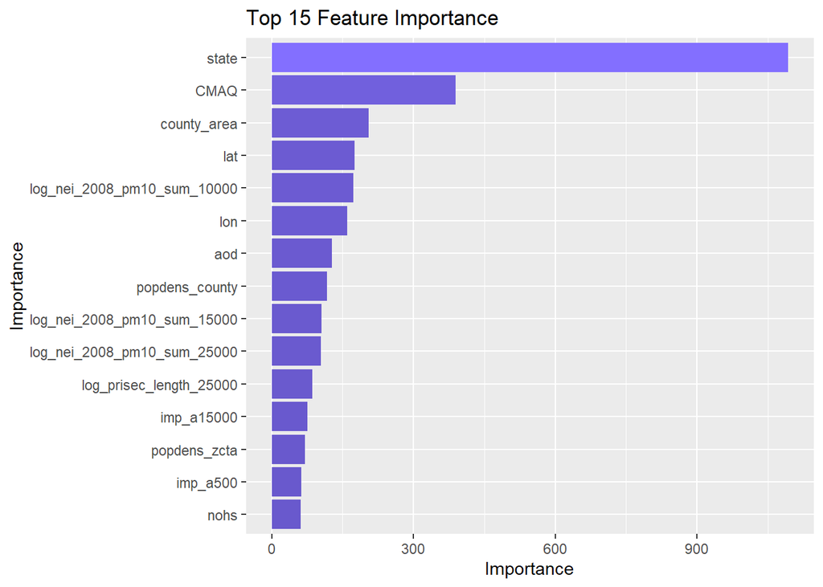

```r
# show the top 15 important features given by the built in function by tidymodels
RF_wflow_fit |>
  extract_fit_parsnip() |>
  vip::vip(num_features = 15) +
  labs(title = "Top 15 Feature Importance", x = "Importance") +
  aes(fill = Importance) +
  scale_fill_gradient(low = "slateblue3", high = "slateblue1")
```

Now we can create the two random forest models similar to the main model that include only the top 10 and top 5 predictors.

```r
# ensure parallelism
n_cores <- parallel::detectCores()
doParallel::registerDoParallel(cores = n_cores)

RF_t10_rec <- recipe(train_pm) |>
    # assign roles for the columns
    update_role(everything(), new_role = "predictor")|>
    update_role(value, new_role = "outcome")|>
    update_role(id, new_role = "id variable") |>
    update_role("fips", new_role = "county id") |>

    # step_novel assigns a previously unseen factor level to a new value
    step_novel("state") |>

    # converts string to factors
    step_string2factor("state", "county", "city") |>

    # removing redundancy
    step_rm("county") |>
    step_rm("zcta") |>

    # removing highly correlated variables
    step_corr(all_numeric()) |>

    # removing near zero variance predictors
    step_nzv(all_numeric()) |>

    # select only top 10 predictors
    step_select(value, state, CMAQ, county_area, lat, log_nei_2008_pm10_sum_10000,
                lon, aod, popdens_county, log_nei_2008_pm10_sum_15000,
                log_nei_2008_pm10_sum_25000)

# creating top 10 workflow with model made in analysis
RF_t10_wflow <- workflows::workflow() |>
  workflows::add_recipe(RF_t10_rec) |>
  workflows::add_model(RF_PM_model)

# fit with the training data set
RF_t10_wflow_fit <- parsnip::fit(RF_t10_wflow, data = train_pm)

# fit with the cross validation
set.seed(456)
resample_t10_RF_fit <- tune::fit_resamples(RF_t10_wflow, vfold_pm)
collect_metrics(resample_t10_RF_fit)
```

```
## # A tibble: 2 × 6
##   .metric .estimator  mean     n std_err .config
##   <chr>   <chr>      <dbl> <int>   <dbl> <chr>
## 1 rmse    standard   1.65      4  0.136  Preprocessor1_Model1
## 2 rsq     standard   0.581     4  0.0481 Preprocessor1_Model1
```

```r
# initializing a tuned random forest model
tune_RF_t10_model <- rand_forest(mtry = tune(), min_n = tune()) |>
  set_engine("randomForest") |>
  set_mode("regression")

# create workflow
RF_t10_tune_wflow <- workflows::workflow() |>
  workflows::add_recipe(RF_t10_rec) |>
  workflows::add_model(tune_RF_t10_model)

# perform hyper parameter tuning for top 10 random forest model using grid search across re samples
set.seed(123)
tune_RF_t10_results <- tune_grid(object = RF_t10_tune_wflow, resamples = vfold_pm, grid = 20)

# results
tune_RF_t10_results |>
  collect_metrics()
```

```
## # A tibble: 40 × 8
##     mtry min_n .metric .estimator  mean     n std_err .config
##    <int> <int> <chr>   <chr>      <dbl> <int>   <dbl> <chr>
##  1     1    14 rmse    standard   1.73      4  0.147  Preprocessor1_Model01
##  2     1    14 rsq     standard   0.575     4  0.0527 Preprocessor1_Model01
##  3     1    24 rmse    standard   1.76      4  0.142  Preprocessor1_Model02
##  4     1    24 rsq     standard   0.563     4  0.0489 Preprocessor1_Model02
##  5     2    34 rmse    standard   1.71      4  0.151  Preprocessor1_Model03
##  6     2    34 rsq     standard   0.575     4  0.0542 Preprocessor1_Model03
##  7     2     6 rmse    standard   1.63      4  0.139  Preprocessor1_Model04
##  8     2     6 rsq     standard   0.610     4  0.0431 Preprocessor1_Model04
##  9     3    18 rmse    standard   1.65      4  0.146  Preprocessor1_Model05
## 10     3    18 rsq     standard   0.595     4  0.0488 Preprocessor1_Model05
## # ℹ 30 more rows
```

```r
# select best model based on rmse
tuned_RF_t10_values<- select_best(tune_RF_t10_results, metric = "rmse")

# specify best combination from tune in workflow
RF_t10_tuned_wflow <-RF_t10_tune_wflow |>
  tune::finalize_workflow(tuned_RF_t10_values)

# fit model with those parameters on train AND test
overallfit_t10 <- RF_t10_wflow |>
  tune::last_fit(pm_split)

test_t10_predictions <- collect_predictions(overallfit)

# build a recipe with only top 5 features
RF_t5_rec <- recipe(train_pm) |>
    # assign roles for the columns
    update_role(everything(), new_role = "predictor")|>
    update_role(value, new_role = "outcome")|>
    update_role(id, new_role = "id variable") |>
    update_role("fips", new_role = "county id") |>

    # step_novel assigns a previously unseen factor level to a new value
    step_novel("state") |>

    # converts string to factors
    step_string2factor("state", "county", "city") |>

    # removing redundancy
    step_rm("county") |>
    step_rm("zcta") |>
    # removing highly correlated variables
    step_corr(all_numeric())|>
    # removing near zero variance predictors
    step_nzv(all_numeric()) |>

    # select only top 5 predictors
    step_select(value, state, CMAQ, county_area, lat, log_nei_2008_pm10_sum_10000)

# creating top 5 workflow with model made in analysis
RF_t5_wflow <- workflows::workflow() |>
  workflows::add_recipe(RF_t5_rec) |>
  workflows::add_model(RF_PM_model)

# fit with the training data set
RF_t5_wflow_fit <- parsnip::fit(RF_t5_wflow, data = train_pm)

# fit with the cross validation
set.seed(456)
resample_t5_RF_fit <- tune::fit_resamples(RF_t5_wflow, vfold_pm)
collect_metrics(resample_t5_RF_fit)
```

```
## # A tibble: 2 × 6
##   .metric .estimator  mean     n std_err .config
##   <chr>   <chr>      <dbl> <int>   <dbl> <chr>
## 1 rmse    standard   1.65      4  0.135  Preprocessor1_Model1
## 2 rsq     standard   0.581     4  0.0518 Preprocessor1_Model1
```

```r
# initialize a tuned random forest model
tune_RF_t5_model <- rand_forest(mtry = tune(), min_n = tune()) |>
  set_engine("randomForest") |>
  set_mode("regression")

# create workflow
RF_t5_tune_wflow <- workflows::workflow() |>
  workflows::add_recipe(RF_t5_rec) |>
  workflows::add_model(tune_RF_t5_model)

# perform hyper parameter tuning for top 5 random forest model using grid search across re samples
set.seed(123)
tune_RF_t5_results <- tune_grid(object = RF_t5_tune_wflow, resamples = vfold_pm, grid = 20)

# results
tune_RF_t5_results |>
  collect_metrics()
```

```
## # A tibble: 40 × 8
##     mtry min_n .metric .estimator  mean     n std_err .config
##    <int> <int> <chr>   <chr>      <dbl> <int>   <dbl> <chr>
##  1     1    14 rmse    standard   1.72      4  0.131  Preprocessor1_Model01
##  2     1    14 rsq     standard   0.570     4  0.0455 Preprocessor1_Model01
##  3     1    24 rmse    standard   1.74      4  0.135  Preprocessor1_Model02
##  4     1    24 rsq     standard   0.561     4  0.0470 Preprocessor1_Model02
##  5     1    34 rmse    standard   1.77      4  0.139  Preprocessor1_Model03
##  6     1    34 rsq     standard   0.546     4  0.0484 Preprocessor1_Model03
##  7     1     6 rmse    standard   1.69      4  0.135  Preprocessor1_Model04
##  8     1     6 rsq     standard   0.583     4  0.0450 Preprocessor1_Model04
##  9     2    18 rmse    standard   1.67      4  0.137  Preprocessor1_Model05
## 10     2    18 rsq     standard   0.579     4  0.0503 Preprocessor1_Model05
## # ℹ 30 more rows
```

```r
# select best model based on rmse
tuned_RF_t5_values<- select_best(tune_RF_t5_results, metric = "rmse")

# specify best combination from tune in workflow
RF_t5_tuned_wflow <-RF_t5_tune_wflow |>
  tune::finalize_workflow(tuned_RF_t5_values)

# fit model with those parameters on train AND test
overallfit_t5 <- RF_t5_wflow |>
  tune::last_fit(pm_split)

test_t5_predictions <- collect_predictions(overallfit)
```

## Results & Discussion

For our results, we will be using the following metrics:

- $adj. r^2$: The adjusted r-squared value, how much a model corresponds to the variance of the predicted values, adjusted to account for the amount of predictors. We use this value to compare the models on a scale of accuracy while also taking into consideration that less features are better. This is a good measure for how parsimonious a model is.
- $rmse$: Root mean squared error, the average error between all predicted and truth values, a metric of distance.

We ran our random forest models on the whole data set to get the following tables:

```
## overall model
```

```
## # A tibble: 2 × 4
##   .metric .estimator .estimate .config
##   <chr>   <chr>          <dbl> <chr>
## 1 rmse    standard       1.71  Preprocessor1_Model1
## 2 rsq     standard       0.611 Preprocessor1_Model1
```

```
## top10 model
```

```
## # A tibble: 2 × 4
##   .metric .estimator .estimate .config
##   <chr>   <chr>          <dbl> <chr>
## 1 rmse    standard       1.84  Preprocessor1_Model1
## 2 rsq     standard       0.532 Preprocessor1_Model1
```

```
## top5 model
```

```
## # A tibble: 2 × 4
##   .metric .estimator .estimate .config
##   <chr>   <chr>          <dbl> <chr>
## 1 rmse    standard       1.93  Preprocessor1_Model1
## 2 rsq     standard       0.497 Preprocessor1_Model1
```

However, there isn’t a built-in measurement for $adj. r^2$ in tidyverse so we would need to create a function to do it ourselves:

```r
# function for calculating adjusted r squared (chatgpt generated)
calculate_adj_r_squared_tidy <- function(predictions, truth_col, estimate_col, num_predictors) {

  # Compute R-squared
  rsq <- rsq_vec(truth_col, estimate_col)

  # Number of observations
  n <- nrow(predictions)

  # Number of predictors
  p <- num_predictors

  # Compute Adjusted R-squared
  adj_r_squared <- 1 - ((1 - rsq) * (n - 1) / (n - p - 1))

  return(adj_r_squared)
}


# we must get the number of predictors for each model using a function (chatgpt generated)
get_predictor_details <- function(workflow_fit) {
  # Extract the final model fit from the workflow
  final_model <- workflows::extract_fit_parsnip(workflow_fit)

  # Extract predictor importance
  predictor_importance <- final_model$fit$importance

  # Get the names of the predictors
  predictor_names <- rownames(predictor_importance)

  # Check the number of predictors
  num_predictors <- length(predictor_names)

  # Return results as a list
  list(
    num_predictors = num_predictors,
    predictor_names = predictor_names,
    predictor_importance = predictor_importance
  )
}

# Collect predictions from the fitted t10 model
test_t10_predictions <- collect_predictions(overallfit_t10)
# Get the number of predictors of the model using a function
num_predictors_t10 <- get_predictor_details(overallfit_t10)$num_predictors
# Use the function to calculate adj r^2
adj_r_squared_t10 <- calculate_adj_r_squared_tidy(
  predictions = test_t10_predictions,
  truth_col = test_t10_predictions$value,
  estimate_col = test_t10_predictions$.pred,
  num_predictors = num_predictors_t10
)

# Collect predictions from the fitted t5 model
test_t5_predictions <- collect_predictions(overallfit_t5)
# Get the number of predictors of the model using a function
num_predictors_t5 <- get_predictor_details(overallfit_t5)$num_predictors
# Use the function to calculate adj r^2
adj_r_squared_t5 <- calculate_adj_r_squared_tidy(
  predictions = test_t5_predictions,
  truth_col = test_t5_predictions$value,
  estimate_col = test_t5_predictions$.pred,
  num_predictors = num_predictors_t10
)

# Collect predictions from the fitted overall model
test_overall_predictions <- collect_predictions(overallfit)
# Get the number of predictors of the model using a function
num_predictors_overall <- get_predictor_details(overallfit)$num_predictors
# Use the function to calculate adj r^2
adj_r_squared_overall <- calculate_adj_r_squared_tidy(
  predictions = test_overall_predictions,
  truth_col = test_overall_predictions$value,
  estimate_col = test_overall_predictions$.pred,
  num_predictors = num_predictors_t10
)
```

```
## overall adj. r^2
```

```
## [1] 0.5966578
```

```
## t10 adj. r^2
```

```
## [1] 0.5157635
```

```
## t5 adj. r^2
```

```
## [1] 0.4787824
```

## Limitations

Although our model may provide a general accuracy in predicting the concentration, there are still several factors to consider when using our model as a representation. It is important to consider that the data used for this study is a decade old and solely measured in the U.S.. Air pollution readings may fluctuate throughout the years and may serve our model as ineffective for future readings. Recent data can be analyzed and implemented into our model for more accurate predictions. Adding on, as the monitor measurements are solely in the U.S., this is not a universal model that we can utilize for other parts of the world. Stated previously, it is also important to consider that our data does not include specific details on the composition of particulate matter. There are several types of particulates that should be considered as they may have a range of effects on human health. We worked on this project through a scientific lens and did not focus on factors from other perspectives. Our analysis is derived from data focused on major biomes in the United States (e.g., states, cities, and counties) and excludes the smaller regions (microbiomes) within. History of racism throughout multiple parts of the United States have made some of these microbiomes - usually non-white neighborhoods - have significantly higher indexes of air pollution compared to white neighborhoods. For instance, in Los Angeles, infrastructure projects were intentionally built through Black and Latino neighborhoods often displacing families and subjecting the people within these communities to higher exposure to pollutants [^3]. As a result, grouping several regions within a city may greatly skew the calculation of the annual average and misrepresent the region’s general air quality. Lastly, we mainly focused on outdoor exposure to pollution and did not take into account individual exposure in private environments and other individual activity. It is said that air fresheners, gas stoves, and exposure to tobacco smoke can also negatively impact one’s health in the long term [^4].

[^1]: https://www.stateofglobalair.org/sites/default/files/soga_2019_report.pdf
[^2]: https://www.stateofglobalair.org/sites/default/files/soga_2019_fact_sheet.pdf
[^3]: https://afrolanews.org/2023/06/unequal-air-the-pollution-legacy-of-segregation-and-the-freeway-boom-in-los-angeles/
[^4]: https://www.epa.gov/indoor-air-quality-iaq/inside-story-guide-indoor-air-quality#:~:text=Some%20sources%2C%20such%20as%20building,after%20some%20of%20these%20activities.